# R Notebook

# LOAD DATASET

```r
library(readxl)
ttestVER <- read_excel("~/Dokumente/02:Weiterbildung/Statistik/R-Notebooks/Projekt/verbunden.xlsx")
#View(ttestVER)
```

# The datasets’ collection:

Mehrere unpassende Datensets gefunden. Letztendlich Datensatz von Frau Wawerda genommen. (verbunden.xlsx)

# Beschreibung

73 Probanden wurden eingeschlossen, die zu zwei Messzeitpunkten untersucht wurden. Es wurde ein Trainingsindex zum Zeitpunkt 1 (kein Training) und zum Zeitpunkt 2 (nach 2 Monaten Training) erhoben.

# Daten:

73 Probanden x 2 Beobachtungen (jeweils zum Zeitpunkt 1 und 2)

# t-Test für abhängige Stichproben

Es wird ein Signifikanzniveau von alpha = 0.05 angenommen.

## Was soll untersucht werden?:

Gibt es einen Mittelwerts-Unterschied bezüglich des Trainingsindex nach 2 Monaten Training im Vergleich zum Startpunkt bei den Probanden?

## Grundlegendes Konzept

Der t-Test für abhängige Stichproben überprüft, ob die Mittelwerte zweier abhängiger/gepaarter Stichproben verschieden sind. Von “abhängigen Stichproben” wird gesprochen, wenn der Messwert und ein bestimmter anderer Messwert sich gegenseitig beeinflussen. In folgende Situationen, die sich für eine verbundene Stichprobe eignen.

Messwiederholung: Die Messwerte stammen von der gleichen Person z.B. Messzeitpunkt #1 verglichen mit Messzeitpunkt #2.

Natürliche Paare: Die Messwerte stammen von verschiedenen Personen, die aber zusammen gehören:Ehefrau – Ehemann, Psychologe – Patient oder Zwillinge.

Matching: Die Messwerte stammen ebenfalls von verschiedenen Personen, die einander zugeordnet wurden. Aufgrund eines vergleichbaren Werts (Drittvariablen) werden Matching-Paare gebildet.

Kurz:Unterscheiden sich die Mittelwerte von zwei abhängigen Stichproben?

## Hypothese

H1: Es gibt einen Unterschied zwischen dem Trainigsindex zum Zeitpunkt T1 und Zeitpunkt T2 (nach 2 Monaten).

H0: Es gibt keinen Unterschied zwischen dem Trainigsindex zum Zeitpunkt T1 und Zeitpunkt T2 (nach 2 Monaten).

## Voraussetzungen

Die abhängige Variable ist min. intervallskaliert -> Ja, der Trainingsindex ist metrisch (intervallskalliert).

Es liegen zwei verbundene Stichproben oder Gruppen vor, aber die verschiedenen Messwertpaare sind voneinander unabhängig. -> 1) Sie sind verbundenen da die gleiche Person betrachtet wird 2) aber unabhängig, weil es verschiedene Testzeitpunkte sind (T1 und T2).

Die Unterschiede zwischen den verbundenen Testwerten sind in der Grundgesamtheit normalverteilt (bei Stichproben > 30 sind Verletzungen unproblematisch) -> n > 30, n = 73, + siehe Histogramm

## Deskriptive Statistik

Daten müssen vorbereitet werden zur korrekten Darstellung.

```r
#Umbenennung der Spalten
names(ttestVER)[2] <- "T1"
names(ttestVER)[3] <- "T2"
```

```r
# Differenz erstellen
zwischen <- ttestVER$`T2`-  ttestVER$`T1`
zwischen
```

```
 [1]  12  11  12  14  12   8  12  14  14  10   5  10   9  11   8  11   8  11   8 -25  10   9  13  10  13  15  15  13   8   8   9  11  10  10
[35]  10  12   9  15  10  12   8  11  11  14  11  14  10  15  11   8  10  12  12  11  11  15  10  14  11  11  15  11   8  12  13   9  14  11
[69]  14   8  11  12  12
```

```r
ttestVER <- cbind(ttestVER, "Differenz" = zwischen)
```

```r
library(psych)
describe(ttestVER)
```

|  | vars | n | mean | sd | median | trimmed | mad | min | max | range | skew | kurtosis | se |
| --- | --- | --- | --- | --- | --- | --- | --- | --- | --- | --- | --- | --- | --- |
| ID | 1 | 73 | 42.73 | 28.69 | 37 | 41.83 | 32.62 | 1 | 92 | 91 | 0.34 | -1.29 | 3.36 |
| T1 | 2 | 73 | 53.00 | 21.05 | 51 | 53.46 | 25.20 | 16 | 85 | 69 | -0.12 | -1.17 | 2.46 |
| T2 | 3 | 73 | 63.64 | 21.22 | 60 | 63.95 | 25.20 | 26 | 97 | 71 | -0.03 | -1.19 | 2.48 |
| Differenz | 4 | 73 | 10.64 | 4.77 | 11 | 11.07 | 1.48 | -25 | 15 | 40 | -5.65 | 39.81 | 0.56 |

Es zeigt sich, dass es einen Mittelwertsunterschied des Trainigsindexes vor und nach dem Training gibt. Die Mittelwerte unterscheiden sich dahingehend, dass die Probanden bei T1 durchschnittlich einen geringen Trainingsindex (M = 53.00, SD = 21.05, n = 73) aufwiesen als Menschen zum Zeitpunkt T2 (M = 63.64, SD = 21.22, n = 73).

## Graphische Darstellung

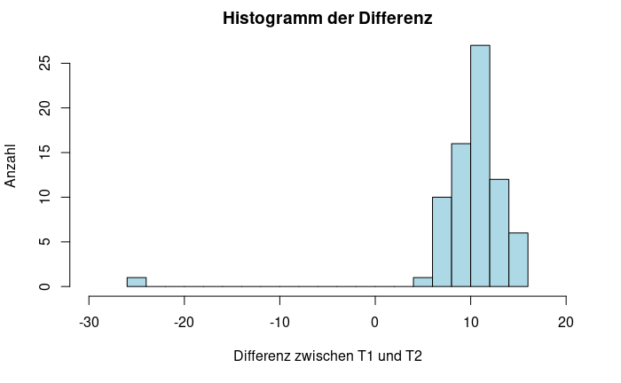

```r
hist(ttestVER$Differenz, xlab = "Differenz zwischen T1 und T2", ylab= "Anzahl", main ="Histogramm der Differenz", breaks =15,  col = "lightblue", xlim = c(-30,20))
```

Hier hatten wir den Verdacht, dass es sich um einen Ausreißer handeln könnte. Zur besseren Darstellung machen wir einen Boxplot.

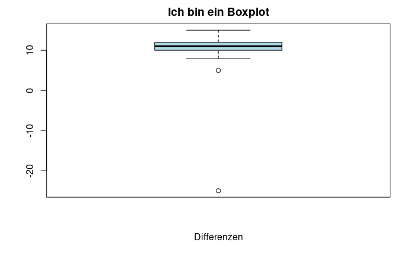

```r
boxplot(ttestVER$Differenz, main = "Ich bin ein Boxplot", xlab = "Differenzen",col = "lightblue")
```

Hier zeigt sich zwei Ausreißer.

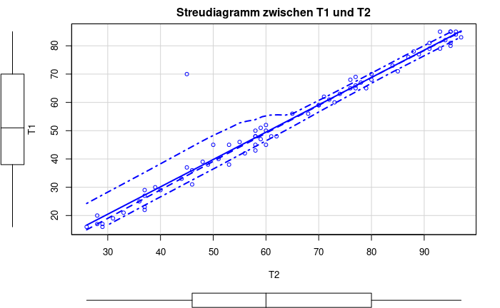

```r
library(car)
scatterplot(ttestVER$`T1` ~ ttestVER$`T2` , main = "Streudiagramm zwischen T1 und T2", xlab = "T2", ylab= "T1")
```

Ein Wertpaar ist eindeutig ein Ausreißer, der zu sehr von dem Gesamtbild / von dem Korrelationsmuster abweicht. Entsprechend haben wir uns dafür entschieden den Ausreißer zu entfernen.

```r
df2<-ttestVER[!(ttestVER$Differenz < "0"),]
```

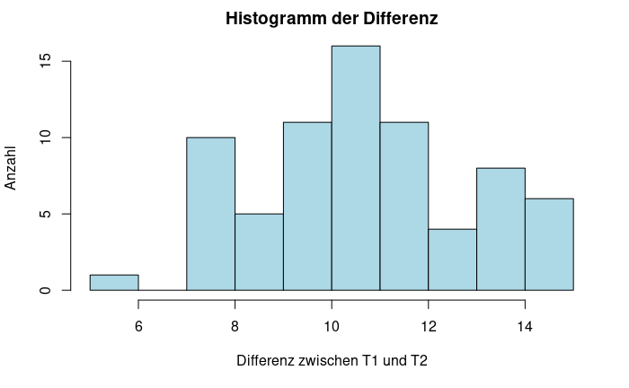

```r
hist(df2$Differenz, xlab = "Differenz zwischen T1 und T2", ylab= "Anzahl", main ="Histogramm der Differenz", breaks =8,  col = "lightblue")
```

Bei diesem Histogramm kann man nach der Datenanpassung eher von einer Normalverteilung ausgehen.

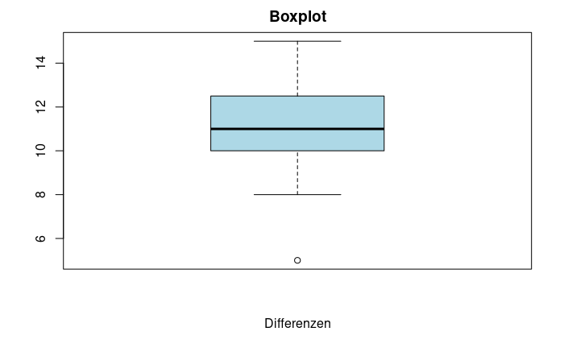

```r
boxplot(df2$Differenz, main = "Boxplot", xlab = "Differenzen",col = "lightblue")
```

Man sieht, dass der Ausreißer entfernt werden konnte.

```
[1] 11 25
```

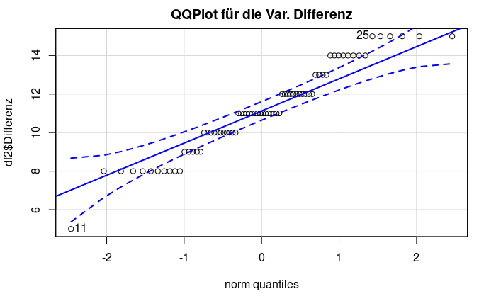

```r
library(car)
qqPlot(df2$Differenz, main = "QQPlot für die Var. Differenz")
```

Diese QQ-Plot lässt vermuten, dass es sich um eine Normalverteilung handelt.

```r
describe(df2)
```

|  | vars | n | mean | sd | median | trimmed | mad | min | max | range | skew | kurtosis | se |
| --- | --- | --- | --- | --- | --- | --- | --- | --- | --- | --- | --- | --- | --- |
| ID | 1 | 72 | 43.04 | 28.77 | 37.5 | 42.21 | 34.10 | 1 | 92 | 91 | 0.32 | -1.30 | 3.39 |
| T1 | 2 | 72 | 52.76 | 21.10 | 50.5 | 53.17 | 25.95 | 16 | 85 | 69 | -0.10 | -1.17 | 2.49 |
| T2 | 3 | 72 | 63.90 | 21.25 | 60.5 | 64.28 | 24.46 | 26 | 97 | 71 | -0.06 | -1.18 | 2.50 |
| Differenz | 4 | 72 | 11.14 | 2.22 | 11.0 | 11.12 | 1.48 | 5 | 15 | 10 | -0.05 | -0.47 | 0.26 |

Durch die Löschung des Datenpunkts verändern sich natürlich auch die Mittelwerte.

Es zeigt sich, dass es einen Mittelwertsunterschied des Trainigsindexes vor und nach dem Training gibt. Die Mittelwerte unterscheiden sich dahingehend, dass die Probanden bei T1 durchschnittlich einen geringen Trainingsindex (M = 52.76, SD = 21.10, n = 72) aufwiesen als Menschen zum Zeitpunkt T2 (M = 63.90, SD = 21.25, n = 72).

Jetzt testen wir noch ob eine Korrelation vorliegt

```r
test <- cor.test(df2$`T1`, df2$`T2`)
test
```

```
    Pearson's product-moment correlation

data:  df2$T1 and df2$T2
t = 79.595, df = 70, p-value < 2.2e-16
alternative hypothesis: true correlation is not equal to 0
95 percent confidence interval:
 0.9912311 0.9965785
sample estimates:
      cor
0.9945208
```

Es liegt eine positive signifikante starke lineare Korrelation vor (r = .995, p < 2.2e-16, n = 72). Hier zeigt sich die “Verbundenheit” der Daten.

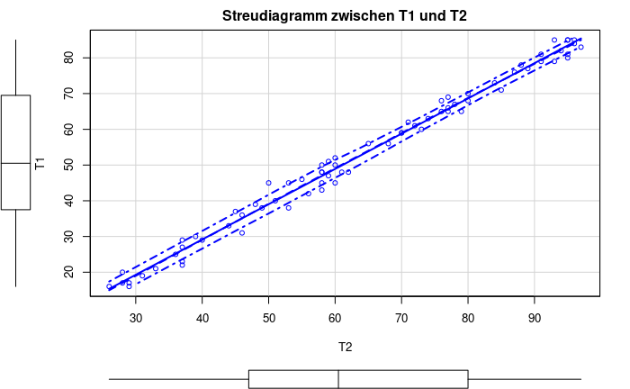

```r
library(car)
scatterplot(df2$`T1` ~ df2$`T2` , main = "Streudiagramm zwischen T1 und T2", xlab = "T2", ylab= "T1")
```

## T-Test für abh. Stichproben

```r
testVER<- t.test(df2$`T2`,df2$`T1`, alternative = "two.sided", paired = TRUE, conf.level = .95)
testVER
```

```
    Paired t-test

data:  df2$T2 and df2$T1
t = 42.533, df = 71, p-value < 2.2e-16
alternative hypothesis: true difference in means is not equal to 0
95 percent confidence interval:
 10.61670 11.66108
sample estimates:
mean of the differences
               11.13889
```

Die Teststatistik beträgt t = 42.533 und der zugehörige Signifikanzwert p < 2.2e-16. Damit ist der Unterschied signifikant: Die Mittelwerte der beiden Messzeitpunkte (Trainingsindex zu Zeitpunkt T1 und T2) unterscheiden sich (t(71) =42.533, p-value < 2.2e-16, n= 72).

## Effektstärke

```r
eff1 <- sqrt(testVER$statistic^2 / (testVER$statistic^2 + testVER$parameter))

sprintf("Effektstärke: %.4f",eff1)
```

```
[1] "Effektstärke: 0.9809"
```

Die Effektstärke beträgt 0.98. Entsprechend handelt es sich um einen starken Effekt nach Cohen (1992)

$$\begin{align}
\text{Schwacher Effekt: } 0.10 &< ||f|| < 0.30\\
\text{Schwacher bis mittlerer Effekt: } 0.30 = ||f|| \\
\text{Mittlerer Effekt: } 0.30 &< ||f|| < 0.50 \\
\text{Mittlerer bis starker Effekt: }0.50 &= ||f|| \\
\text{Starker Effekt: } 0.50 &< ||f||
\end{align}$$

# Aussage

Es zeigt sich, dass die Trainsindexe im Vergleich der Zeitpunkte T1 und T2 signifikant unterscheiden (t(71) =42.533, p-value < 2.2e-16, n= 72). Der Trainingsindex vor dem Training (M = 52.76, SD = 21.10, n = 72) fällt niedriger aus, als der Trainingsindex nach den 2 Monaten Training (M = 63.90, SD = 21.25, n = 72). Die Effektstärke nach Cohen (1992) liegt bei r = 0.98 und entspricht damit einem starken Effekt. Die H0 kann verworfen werden.